# Tvyal Newsletter

Aghasi Tavadyan

2024-01-12

*English summary below.*

Հարգելի գործընկեր,

Հուսով եմ լավ եք: Ներկայացնում եմ այս շաբաթվա վերլուծությունները և աշխատանքները.

1. Երևանը Մոսկվայից ավելի թանկ է
2. ԶԼՄ հաղորդագրություններ
3. English summary

## 1. Երևանը Մոսկվայից ավելի թանկ է

Ըստ [Numbeo․com](https://www.numbeo.com/cost-of-living/) կայքի Երևանում ապրուստը 2023 թվականին ամենաթանկն է եղել մեր հարևան երկրների համեմատ։ [Երևանում ապրելն ավելի թանկ է, քան նույնիսկ Մոսկվայում](https://www.numbeo.com/cost-of-living/compare_cities.jsp?country1=Russia&city1=Moscow&country2=Armenia&city2=Yerevan&displayCurrency=USD)։

[figure not shown]

Ըստ այս աղբյուրի կյանքի նույն որակը ապահովելու համար անհատին անհրաժեշտ կլինի ամսական [3,246,3 դոլար (1,312,852.0 դրամ) Երևանում, իսկ Մոսկվայում՝ 2,909,4 դոլար (260,000.0 ռուբլի)](https://www.numbeo.com/cost-of-living/compare_cities.jsp?country1=Russia&city1=Moscow&country2=Armenia&city2=Yerevan&displayCurrency=USD)։ Այս գումարի մեջ է մտնում նաև նույն որակի տան վարձակալությունը, որը Երևանի կենտրոնում 1 սենյականոց բնակարանի համար գրեթե 1000 դոլար էր 2023 թվականին: Ըստ այս տվյալների տարածաշրջանի քաղաքների համեմատ Երևանում ապրուստը ամենաթանկն է։

- Սպառողական գները Երևանում 15,1%-ով բարձր են, քան Մոսկվայում (առանց վարձակալության)
- Երևանում սպառողական գները ներառյալ վարձավճարը 11,6%-ով բարձր են, քան Մոսկվայում
- Երևանում վարձակալության գները 4,8%-ով բարձր են, քան Մոսկվայում
- Ռեստորանային գները Երևանում 21,8%-ով բարձր են, քան Մոսկվայում
- Մթերքները Երևանում 17,6%-ով բարձր են, քան Մոսկվայում
- Տեղական գնողունակությունը Երևանում 56,9%-ով ցածր է, քան Մոսկվայում

[Numbeo․com](https://www.numbeo.com/common/about.jsp) կայքին վստահում են BBC, Time, Forbes, The Economist, Business Insider, New York Times, The Telegraph և այլ հայտնի պարբերականները։ Այս հարթակը հաշվարկում է կյանքի արժեքի, կյանքի որակի և տարբեր սոցիալ-տնտեսական գործոնների վերաբերյալ ճշգրիտ և արդի տեղեկատվություն ամբողջ աշխարհի քաղաքներում և երկրներում:

**Գծապատկեր 1.**

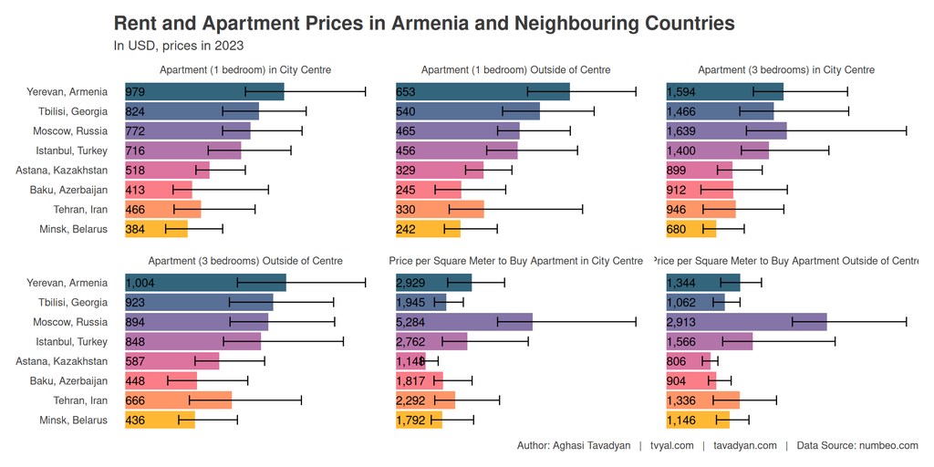

Նշեմ որ, 2021 թվականին 45 ք․մ․ բնակարանի վարձակալության արժեքը Երևանի կենտրոնում կազմում էր մոտ 700 դոլար, 2022 թվականի սեպտեմբերից մինչև 2023 թվականի սեպտեմբերը արդեն՝ 1000 դոլար։ Սակայն այժմ նմանատիպ բնակարանի վարձակալության գինը իջել է 750 դոլար։ Հավանական է, որ սա սեզենային բնույթ ունի, քանզի ձմռան սեզոնին պահանջարկը ավելի ցածր է և վարձակալության գները ամռանը ունեն բարձրանալու միտում։ Սակայն 2022-23 թվականի ձմռանը բնակարանների գնի սեզոնային իջեցում չնկատվեց, քանզի առկա էր ՌԴ քաղաքացիների մեծ ներհոսք։ ՌԴ քաղաքացիները հոսքը ունի միջնաժամկետ բնույթ և հնարավոր է որ 2024 թվականին վարձակալության գները ավելի ցածր լինեն 2023 թվականի համեմատ։

Հաջորդ գծապատկերը ցույց է տալիս ռեստորան այցելելու արժեքը արժեքը Հայաստանում և հարևան երկրներում։ Ինչպես երևում է գծապատկերից ռեստորան այցելությունը նույնպես ավելի թանկ է նույնիսկ համեմատած Մոսկվայի հետ։ 2 հոգու համար 3 ուտեստից բաղկացած կերակուրի արժեքը Երևանի ռեստորանում կազմում է 20 հազար դրամ, իսկ Մոսկվայում մոտ 14 հազար դրամ։ Ըստ տվյալների արագ սնունդը և մասսայական ռեստորաններում սնունդը ամենաթանկը Թբիլիսիում է, որից հետո գալիս է Երևանը։

**Գծապատկեր 2.**

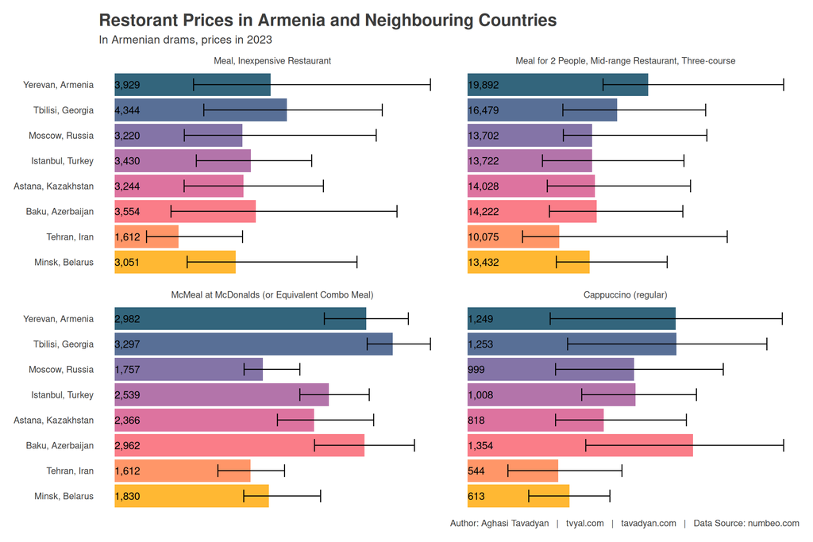

Երևանում թանկ է նաև բրենդային հագուտը։ Ասիայի բոլոր քաղաքներից, որոնք գրանցվեծ են Numbeo․com կայքում Երևանում միջին դասի Nike վազքի կոշիկները գնով ամենաթակն 2-րդ տեղում են։ [Տես՝ Rankings, History and Analysis](https://www.numbeo.com/cost-of-living/in/Yerevan)

**Գծապատկեր 3.**

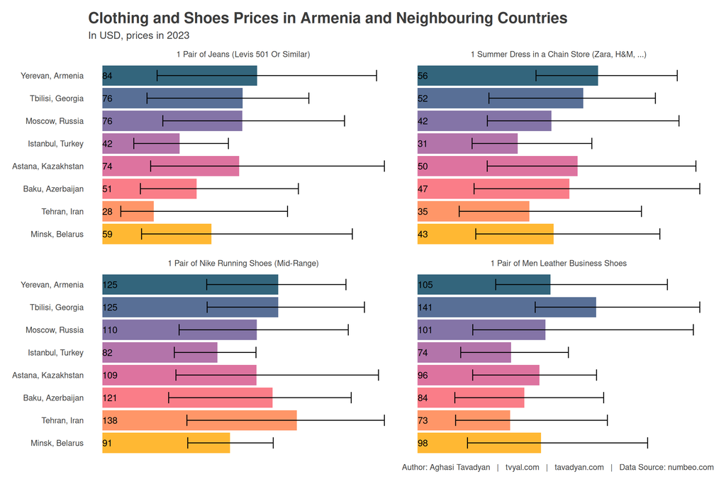

Ստորև ներկայացված է նաև տվյալ տարածաշրջանի ամենահանրաժան կամ պոպուլյար քաղաքները ըստ Numbeo․com կայքում Ներկայացված գրառումներումների քանակի։

**Գծապատկեր 4.**

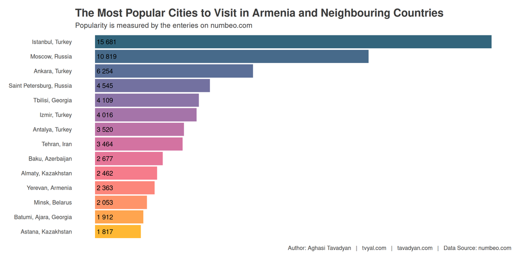

Երևանը զբաղեցնում է 11-րդ տեղը ըստ գրառումների քանակի և առաջին տեղը ըստ նույն որակը ապահովելու ապրուստի ծախսերի։ Ներկայացված տվյալները նախանշում են որ այստեղ առկա է որոշակի անհավասարակշռություն, որը առաջացել է Ռուսաստանի դեմ պատժամիջոցներից և դեպի Հայաստան համեմատաբար մեծ քանակությամբ ՌԴ քաղաքացիների և կապիտալի ներհոսքից։ Այպիսի ներքոսը չի կարող ունենալ շարունակական բնույթ, որը արդեն իսկ [երևում է տվյալներով (տես՝ Գծապատկեր 2 և 3, Հայաստան կատարված դրամական փոխանցումներ)](https://www.tvyal.com/newsletter/2023_10_16)։ Այս անհավասարակշռությունը ունի որոշակի վտանգներ։ Եթե ՌԴ քաղաքացիները Հայաստանում երկարատև չհաստատվեն և դեպի Ռուսաստանի կապիտալի ներհոսքը վերականգնվի, ([որի նախանշանները արդեն առկա են](https://www.tvyal.com/newsletter/2023_10_23)) ապա Հայաստանում գները կարող են ընկանել՝ հատկապես վարձակալության և վաճառքի, որը տնտեսական աճի տեսանկյունից կունենա բացասական հետևանք, քանզի Հայաստանտան մտած կապիտալը հիմնականում ներդրվում է շինարարության մեջ։

Նշեմ, որ Numbeo․com կայքից վերծանված տվյալների բազաները կարող եք գտնել նաև մեր [Github-ում](https://github.com/tavad/tvyal_newsletter/2024)։

## 2. ԶԼՄ հաղորդագրություններ

Այս շաբաթ հարցազրույց եմ տվյալ 1in.am լրատվամիջոցին, որտեղ ամփոփել եմ այս և [անցած շաբաթվա հետազոտությունները](https://www.tvyal.com/newsletter/2024/2024_01_07)

Հարցազրույցի անվանումն է՝ [Երևանում հարուստները ավելի են հարստացել, աղքատները՝ ավելի աղքատացել, մարզերում հիմնականում աղքատացել են](https://youtu.be/D0CsyhYC9Zo)

[figure not shown]

Առկա է նաև այս հարցազրույցի [youtube short-ը](https://www.youtube.com/shorts/11oDLyh4ukw)։

[figure not shown]

## 3. English Summary

**Yerevan is More Expensive than Moscow in 2023**

In 2023, living in Yerevan surpassed Moscow as the most expensive among neighboring cities, according to Numbeo.com. To maintain an equivalent quality of life, an individual needs $3,246.3 per month in Yerevan compared to $2,909.4 in Moscow, including rent. Consumer prices in Yerevan are 15.1% higher than in Moscow, with 4.8% higher rental prices. The surge in rental costs in Yerevan is attributed to an influx of Russian citizens, while in Moscow, prices fell due to sanctions. The impact of this imbalance poses economic risks for Armenia, as a potential return of capital to Russia could lead to a decline in prices, especially in the real estate sector.

Despite a recent drop in rental prices from $1,000 to $750 for a similar apartment in Yerevan, seasonal fluctuations and the influx of Russian citizens may influence 2024 prices. Additionally, Yerevan stands out in restaurant costs, with a 3-course meal for two being more expensive than in Moscow. Branded clothes, particularly mid-range Nike running shoes, are also relatively pricier in Yerevan compared to other Asian cities. The data suggests a temporary imbalance driven by the influx of Russian citizens and capital, posing potential economic challenges if the trend reverses in the future.

## Այս վերլուծությունը առկա է նաև [մեր կայքէջում](https://www.tvyal.com/newsletter/2024/2024_01_12), այս վերլուծության կոդը և տվյալները դրված են նաև [Github-ում](https://github.com/tavad/tvyal_newsletter)։

Եթե հնարավոր է, խնդրում եմ այս նյութը ուղարկել նաև այն մարդկանց, ում այն կարծում եք կարող է հետաքրքրել:

Սպասեք հաջորդ հաղորդագրությանը հաջորդ ուրբաթ օրը:

Հարգանքներով,  
Աղասի Թավադյան  
12.01.2024  
[tvyal.com](https://www.tvyal.com/)  
[tavadyan.com](https://www.tavadyan.com/)

[Was this email forwarded to you? Subscribe here.](https://www.tvyal.com/subscribe)

[Բաժանորդագրվեք](https://www.tvyal.com/subscribe)

**Ուշադրություն. Ձեր էլ.փոստը մեյլիսթի մեջ է, որի միջոցով ես կիսվում եմ շաբաթական նյութեր, որոնք հիմնականում ներկայացնում են Հայաստանի տնտեսությանը: Նյութերը ներառում են գծապատկերներ, [տվյալների բազաներ](https://github.com/tavad/tvyal_newsletter), տեսանյութեր, հոդվածներ, [առցանց վահանակներ](https://www.tvyal.com/projects), տնտեսական գործիքներ, կանխատեսումներ և հաշվետվություններ: Եթե ցանկանում եք չեղարկել բաժանորդագրությունը, խնդրում եմ տեղեկացրեք ինձ, և ես կհեռացնեմ ձեր էլ. փոստը ցուցակից: Գրեք նաև եթե ունեք մենկնաբանություններ:**

**Important! Your email is part of the mailing list where I share weekly materials primarily focused on the Armenian economy. These materials encompass charts, [databases](https://github.com/tavad/tvyal_newsletter), videos, articles, [online dashboards](https://www.tvyal.com/projects), economic tools, forecasts, and reports. If you wish to unsubscribe, please let me know, and I will remove your email from the list. Please share your comments as well․**